# Null Threshold Search for Survival Outcomes

Approximation-Driven Selection with Simulation Validation (GBSG DGM)

Author

Larry F. Leon

Published

April 1, 2026

# 1 Introduction

## 1.2 $L_{\text{eff}}$ Calibration Source

$$\text{FPR}_{\text{corr}}(N) = 1 - (1 - P_1)^{L_{\text{eff}}(N)},
\qquad
L_{\text{eff}}(N) = C \cdot (N / n_{\min})^\alpha$$

Prior calibration (from `calibration_survival_fourway.qmd`, GBSG survival DGM, 7 confounders): loaded from `_data/calibration_survival_leff.rds` if available, otherwise falls back to $C = 0.029$, $\alpha = 0.882$.

Note: For survival, $L_{\text{eff}} < 1$ at typical sample sizes because the events-based filters (`d0.min`, `d1.min`) aggressively prune candidates. The paper defaults (c1 = 1.25, c2 = 1.0) are already conservative for survival.

# 2 Setup

```r
library(forestsearch)
library(weightedsurv)
library(data.table)
library(survival)
library(ggplot2)
library(patchwork)
library(gt)
library(foreach)
library(doFuture)
library(future)

# L_eff save/load helpers
#source(here::here("../R", "leff_calibration_io.R"))
```

```r
# Load L_eff calibration from C2 (calibration_survival_fourway.qmd)
# Falls back to hardcoded values if .rds not found
cal_survival <- tryCatch(
  load_leff_calibration("survival", output_dir = output_dir),
  error = function(e) {
    message("Calibration .rds not found: ", e$message)
    message("Using fallback values: C=", C_prior_fallback,
            ", alpha=", alpha_prior_fallback)
    list(C = C_prior_fallback, alpha = alpha_prior_fallback,
         n_min = 60L, source = "fallback (hardcoded)")
  }
)

C_prior     <- cal_survival$C
alpha_prior <- cal_survival$alpha

cat(sprintf("L_eff prior: C = %.4f, alpha = %.4f\n",
            C_prior, alpha_prior))
```

```
#> L_eff prior: C = 0.6305, alpha = -0.3894
```

```r
if (!is.null(cal_survival$dgm_description))
  cat(sprintf("Source: %s\n", cal_survival$dgm_description))
```

```
#> Source: GBSG survival DGM, 7 confounders (z1-z5, size, grade3), prop_cens=0.46, p_harm=0.13
```

```r
if (!is.null(cal_survival$timestamp))
  cat(sprintf("Calibrated: %s\n",
              format(cal_survival$timestamp, "%Y-%m-%d %H:%M")))
```

```
#> Calibrated: 2026-04-01 21:13
```

```r
timings <- list()
t_vignette_start <- proc.time()
```

```r
plan(multisession, workers = n_workers)
cat("Using", n_workers, "parallel workers\n")
```

```
#> Using 121 parallel workers
```

```r
cat("Validation sims per config:", nsims_val, "\n")
```

```
#> Validation sims per config: 500
```

```r
cat("FPR target:", fpr_target, "\n")
```

```
#> FPR target: 0.12
```

```r
cat("Recalibrate L_eff:", recalibrate, "\n")
```

```
#> Recalibrate L_eff: TRUE
```

# 3 Null DGM

```r
t0 <- proc.time()[3]

dgm_null <- setup_gbsg_dgm(model = "null", k_treat = 1.0,
                             verbose = TRUE)

cat("\nNull DGM:\n")
```

```
#>
#> Null DGM:
```

```r
cat("  HR(ITT):", round(dgm_null$hr_causal, 3), "\n")
```

```
#>   HR(ITT): 0.722
```

```r
cat("  AHR:", round(dgm_null$AHR, 3), "\n")
```

```
#>   AHR: 0.654
```

```r
timings$dgm <- proc.time()[3] - t0
```

# 4 Part I: $L_{\text{eff}}$ Calibration

## 4.1 Background

For survival, $L_{\text{eff}}$ is typically less than 1 because the events-based filters (`d0.min`, `d1.min`) prune most candidate subgroups before they reach the threshold check. This means the procedure is *more conservative* than a single per-subgroup test, and the paper defaults (c1 = 1.25, c2 = 1.0) provide strong FPR control.

## 4.2 Shared Parameters

```r
n_min_val <- 60
prop_cens <- 0.46
p_harm    <- 0.13     # Prevalence of harm subgroup in GBSG DGM
pcons     <- 0.90

# Subgroup characteristics at reference N = 700
n_H_ref <- round(p_harm * 700)
d_dgm <- round(d_eff_survival(n_H_ref, prop_cens))
cat(sprintf("Reference: N=700, n_H=%d, d_eff=%d events\n",
            n_H_ref, d_dgm))
```

```
#> Reference: N=700, n_H=91, d_eff=49 events
```

```r
p_detect_glm <- function(theta, d_eff, c1, c2) {
  compute_detection_probability_glm(
    theta = theta, d_eff = d_eff, c1 = c1, c2 = c2,
    effect_scale = "ratio", method = "monte_carlo"
  )
}

# Simulation parameters for calibration / validation
confounders_base <- c("z1", "z2", "z3", "z4", "z5",
                       "size", "grade3")

fs_params_base <- list(
  hr.threshold = 1.25,
  hr.consistency = 1.0,
  pconsistency.threshold = pcons,
  fs.splits = 400,
  n.min = n_min_val,
  d0.min = 12, d1.min = 12,
  maxk = 2, by.risk = 12,
  vi.grf.min = -0.2,
  use_lasso = TRUE, use_grf = TRUE,
  use_twostage = TRUE, twostage_args = list()
)

fs_params_cox <- modifyList(fs_params_base, list(
  outcome.name = "y_sim", event.name = "event_sim",
  treat.name = "treat_sim", id.name = "id"
))

sim_config <- list(
  n_sample = 700, analysis_time = 84,
  cens_adjust = log(1.5)
)
```

## 4.3 Calibration Simulation

```r
if (recalibrate) {
  N_cal_values <- c(300, 500, 700, 1000)

  cat(sprintf("=== L_eff Calibration ===\n"))
  cat(sprintf("Reference thresholds: c1=1.25, c2=1.0\n"))
  cat(sprintf("N values: %s\n", paste(N_cal_values, collapse=", ")))
  cat(sprintf("Sims per N: %d\n\n", n_sims_recal))

  t0 <- proc.time()[3]

  cal_results <- list()
  for (N_val in N_cal_values) {
    t_N <- proc.time()[3]

    res_N <- foreach(
      sim = seq_len(n_sims_recal),
      .combine = rbind, .errorhandling = "remove",
      .options.future = list(
        packages = c("forestsearch", "survival", "data.table"),
        seed = TRUE)
    ) %dofuture% {
      run_simulation_analysis(
        sim_id = sim, dgm = dgm_null,
        n_sample = N_val,
        analysis_time = sim_config$analysis_time,
        cens_adjust = sim_config$cens_adjust,
        confounders_base = confounders_base,
        cox_formula_adj = survival::Surv(y_sim, event_sim) ~
          treat_sim + z1 + z2 + z3,
        n_add_noise = 0L,
        run_fs = TRUE, run_fs_grf = FALSE, run_grf = FALSE,
        fs_params = fs_params_cox, verbose = FALSE
      )
    }

    fs_rows <- res_N[res_N$analysis == "FS", ]
    fpr_N <- mean(fs_rows$any.H, na.rm = TRUE)
    cal_results[[as.character(N_val)]] <- data.frame(
      N = N_val, sim_fpr = fpr_N, n_sims = nrow(fs_rows)
    )
    cat(sprintf("  N = %4d: FPR = %.3f (%d sims) | %.1f sec\n",
        N_val, fpr_N, nrow(fs_rows), proc.time()[3] - t_N))
  }

  timings$leff_cal <- proc.time()[3] - t0
  cat(sprintf("\nCalibration: %.1f min\n", timings$leff_cal / 60))

} else {
  timings$leff_cal <- 0
  cat("Calibration skipped (recalibrate = FALSE).\n")
  cat("Using prior values from calibration_survival_fourway.\n")
}
```

```
#> === L_eff Calibration ===
#> Reference thresholds: c1=1.25, c2=1.0
#> N values: 300, 500, 700, 1000
#> Sims per N: 200
```

```
#>   N =  300: FPR = 0.065 (200 sims) | 45.8 sec
```

```
#>   N =  500: FPR = 0.080 (200 sims) | 38.5 sec
```

```
#>   N =  700: FPR = 0.040 (200 sims) | 41.3 sec
```

```
#>   N = 1000: FPR = 0.030 (200 sims) | 35.6 sec
#>
#> Calibration: 2.7 min
```

## 4.4 Fit $L_{\text{eff}}$ Power Law

```
#> === Implied L_eff ===
#>         N n_H d_eff       P1 sim_fpr     L_eff
#> 300   300  39    21 0.211932   0.065 0.2821871
#> 500   500  65    35 0.189840   0.080 0.3960679
#> 700   700  91    49 0.170376   0.040 0.2185534
#> 1000 1000 130    70 0.144978   0.030 0.1944684
#> L_eff Calibration
#>   Model: L_eff = 0.630 * (N / 60)^-0.389
#>   R-squared: 0.401
#>   Calibrated at N = 300, 500, 700, 1000
#>
#>   Implied L_eff:
#>     N =  300: L_eff = 0.28 (fitted: 0.34)
#>     N =  500: L_eff = 0.40 (fitted: 0.28)
#>     N =  700: L_eff = 0.22 (fitted: 0.24)
#>     N = 1000: L_eff = 0.19 (fitted: 0.21)
```

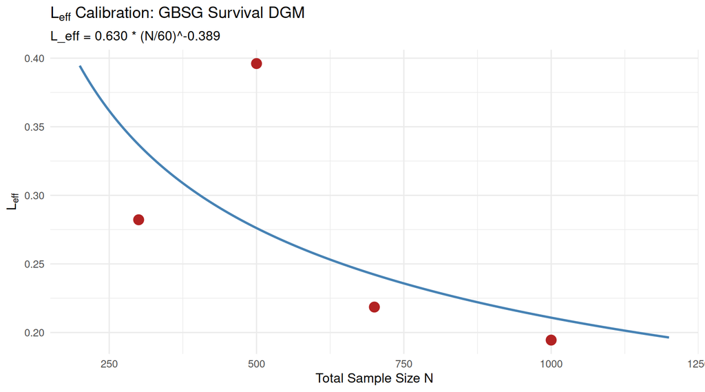

L_eff calibration for the GBSG survival DGM (only shown when recalibrate = TRUE).

```r
if (recalibrate) {
  cal_df <- do.call(rbind, cal_results)
  cal_df$n_H <- round(p_harm * cal_df$N)
  cal_df$d_eff <- round(d_eff_survival(cal_df$n_H, prop_cens))
  cal_df$P1 <- sapply(cal_df$d_eff, function(d)
    p_detect_glm(1.0, d, 1.25, 1.0))

  cal_df$sim_fpr <- pmax(cal_df$sim_fpr, 0.5 / n_sims_recal)
  cal_df$sim_fpr <- pmin(cal_df$sim_fpr, 1 - 0.5 / n_sims_recal)
  cal_df$L_eff <- log(1 - cal_df$sim_fpr) / log(1 - cal_df$P1)

  cat("=== Implied L_eff ===\n")
  print(cal_df[, c("N", "n_H", "d_eff", "P1",
                    "sim_fpr", "L_eff")])

  cal_valid <- cal_df[is.finite(cal_df$L_eff) &
                       cal_df$L_eff > 0, ]

  if (nrow(cal_valid) >= 2) {
    leff_cal <- calibrate_L_eff(
      N = cal_valid$N, P1 = cal_valid$P1,
      sim_fpr = cal_valid$sim_fpr, n_min = n_min_val
    )
    C_fit <- leff_cal$C
    alpha_fit <- leff_cal$alpha
    print(leff_cal)

    N_pred <- seq(200, 1200, by = 5)
    pred_curve <- data.frame(
      N = N_pred,
      L_eff = C_fit * (N_pred / n_min_val)^alpha_fit
    )

    print(
      ggplot() +
        geom_point(data = cal_valid, aes(x = N, y = L_eff),
                   size = 4, colour = "firebrick") +
        geom_line(data = pred_curve, aes(x = N, y = L_eff),
                  colour = "steelblue", linewidth = 1) +
        labs(x = "Total Sample Size N",
             y = expression(L[eff]),
             title = expression(
               L[eff] * " Calibration: GBSG Survival DGM"),
             subtitle = sprintf(
               "L_eff = %.3f * (N/%d)^%.3f",
               C_fit, n_min_val, alpha_fit)) +
        theme_minimal(base_size = 12) +
        theme(plot.title = element_text(face = "bold"))
    )
  } else {
    cat("Insufficient calibration points; using prior.\n")
    C_fit <- C_prior; alpha_fit <- alpha_prior
  }

} else {
  C_fit <- C_prior
  alpha_fit <- alpha_prior
  cat(sprintf("Using prior: C = %.3f, alpha = %.3f\n",
              C_fit, alpha_fit))
}
```

## 4.5 $L_{\text{eff}}$ Summary

```r
N_target <- c(300, 500, 700, 1000)

cat("=== L_eff Model ===\n")
```

```
#> === L_eff Model ===
```

```r
cat(sprintf("  L_eff(N) = %.3f * (N/%d)^%.3f\n\n",
            C_fit, n_min_val, alpha_fit))
```

```
#>   L_eff(N) = 0.630 * (N/60)^-0.389
```

```r
cat("=== L_eff at Target Sample Sizes ===\n")
```

```
#> === L_eff at Target Sample Sizes ===
```

```r
for (N_val in N_target) {
  L <- C_fit * (N_val / n_min_val)^alpha_fit
  cat(sprintf("  N = %4d: L_eff = %.2f\n", N_val, L))
}
```

```
#>   N =  300: L_eff = 0.34
#>   N =  500: L_eff = 0.28
#>   N =  700: L_eff = 0.24
#>   N = 1000: L_eff = 0.21
```

```r
cat(sprintf("\n=== Source: %s ===\n",
  if (recalibrate) "calibrated in this run" else "prior"))
```

```
#>
#> === Source: calibrated in this run ===
```

```r
cat("\nNote: L_eff < 1 means the procedure is MORE conservative\n")
```

```
#>
#> Note: L_eff < 1 means the procedure is MORE conservative
```

```r
cat("than a single per-subgroup test (events filters prune candidates).\n")
```

```
#> than a single per-subgroup test (events filters prune candidates).
```

## Adapting for Other Scenarios

**TipBlueprint: How to Calibrate for a New Survival DGM**

**Step 1.** Replace `setup_gbsg_dgm()` / `simulate_from_dgm()` with your H0 data generator.

**Step 2.** Update `confounders_base` and `fs_params_cox` to match your analysis configuration.

**Step 3.** Update `p_harm` (harm subgroup prevalence) and `prop_cens` (censoring proportion) for `d_eff_survival()`.

**Step 4.** Set `recalibrate = TRUE` and `n_sims_recal` to at least 200.

**Step 5.** After the calibration run, record the fitted $C$ and $\alpha$ as your new `C_prior` / `alpha_prior`.

# 5 Part II: Approximation-Driven Selection

## 5.1 Dense Approximation Grid

```r
c1_grid <- seq(1.00, 1.80, by = 0.05)
c2_grid <- seq(0.90, 1.50, by = 0.05)

full_grid <- expand.grid(c1 = c1_grid, c2 = c2_grid,
                          N = N_target,
                          stringsAsFactors = FALSE)
full_grid <- full_grid[full_grid$c2 <= full_grid$c1, ]

# Compute corrected FPR for every (c1, c2, N)
full_grid$n_H <- round(p_harm * full_grid$N)
full_grid$d_eff <- round(d_eff_survival(full_grid$n_H, prop_cens))
full_grid$L_eff <- C_fit * (full_grid$N / n_min_val)^alpha_fit

full_grid$P1 <- mapply(function(d, c1v, c2v) {
  p_detect_glm(1.0, d, c1v, c2v)
}, full_grid$d_eff, full_grid$c1, full_grid$c2)

full_grid$FPR_corr <- 1 - (1 - full_grid$P1)^full_grid$L_eff

full_dt <- data.table(full_grid)

cat(sprintf("Dense grid: %d c1 x %d c2 x %d N = %d configs\n",
    length(c1_grid), length(c2_grid), length(N_target),
    nrow(full_dt)))
```

```
#> Dense grid: 17 c1 x 13 c2 x 4 N = 656 configs
```

## 5.2 Corrected FPR Heatmaps

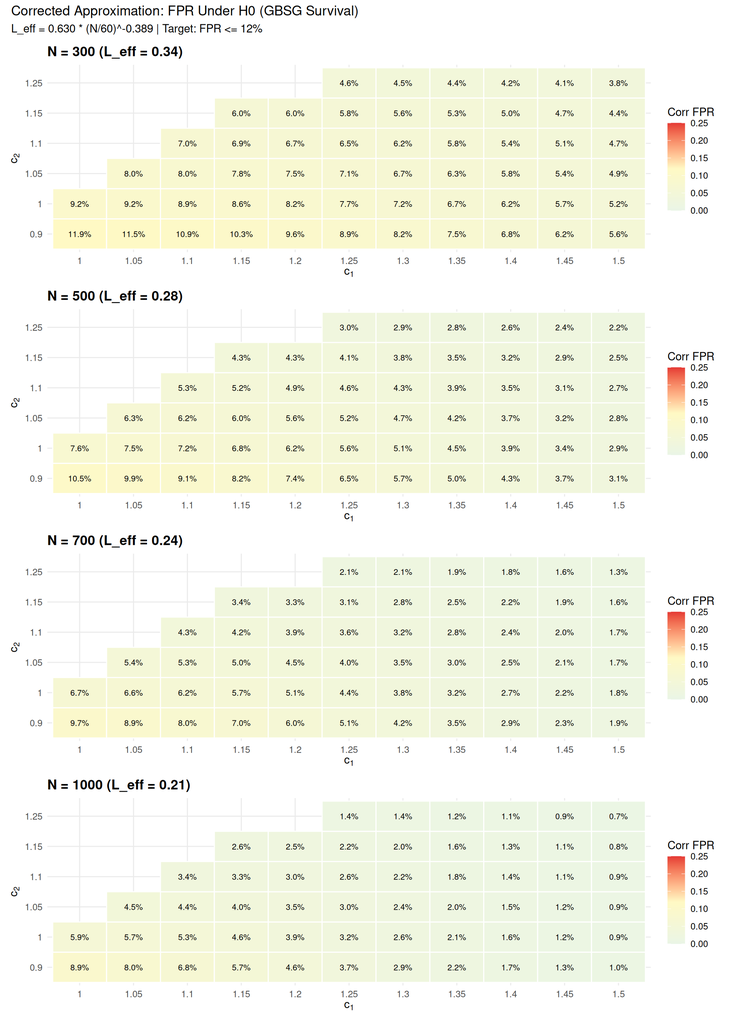

Corrected approximation FPR. For survival with L_eff < 1, the corrected FPR is LOWER than P1.

```r
c1_heat <- seq(1.00, 1.50, by = 0.05)
c2_heat <- c(0.90, 0.95, 1.00, 1.05, 1.10, 1.15, 1.20, 1.25)

heat_sub <- full_dt[c1 %in% c1_heat & c2 %in% c2_heat]

heatmap_list <- lapply(N_target, function(N_val) {
  sub <- heat_sub[N == N_val]
  ggplot(sub, aes(x = factor(c1), y = factor(c2),
                  fill = FPR_corr)) +
    geom_tile(colour = "white", linewidth = 0.5) +
    geom_text(aes(label = sprintf("%.1f%%", 100 * FPR_corr)),
              size = 2.8, colour = "black") +
    scale_fill_gradient2(
      low = "#E8F5E9", mid = "#FFF9C4", high = "#E53935",
      midpoint = fpr_target,
      limits = c(0, max(heat_sub$FPR_corr, 0.25)),
      name = "Corr FPR"
    ) +
    labs(x = expression(c[1]), y = expression(c[2]),
         title = sprintf("N = %d (L_eff = %.2f)", N_val,
           C_fit * (N_val / n_min_val)^alpha_fit)) +
    theme_minimal(base_size = 11) +
    theme(plot.title = element_text(face = "bold"),
          axis.text = element_text(size = 9))
})

wrap_plots(heatmap_list, ncol = 1) +
  plot_annotation(
    title = "Corrected Approximation: FPR Under H0 (GBSG Survival)",
    subtitle = sprintf(
      "L_eff = %.3f * (N/%d)^%.3f | Target: FPR <= %.0f%%",
      C_fit, n_min_val, alpha_fit, 100 * fpr_target))
```

## 5.3 Pre-Select: Smallest $(c_1, c_2)$ Meeting the Target

```r
N_max <- max(N_target)
fpr_wide <- full_dt[, .(
  FPR_corr_worst = FPR_corr[N == N_max]
), by = .(c1, c2)]

for (N_val in N_target) {
  col_name <- sprintf("FPR_N%d", N_val)
  fpr_wide[[col_name]] <- full_dt[N == N_val,
    FPR_corr[match(paste(fpr_wide$c1, fpr_wide$c2),
                   paste(c1, c2))]]
}

selected <- fpr_wide[FPR_corr_worst <= fpr_target]
setorder(selected, c1, c2)

cat(sprintf(
  "Pairs with corrected FPR <= %.0f%% at N=%d: %d of %d\n",
  100 * fpr_target, N_max, nrow(selected), nrow(fpr_wide)))
```

```
#> Pairs with corrected FPR <= 12% at N=1000: 164 of 164
```

```r
# Frontier
frontier <- selected[, .(
  min_c2 = min(c2),
  FPR_at_min_c2 = FPR_corr_worst[which.min(c2)]
), by = c1]
setorder(frontier, c1)

if (nrow(frontier) > 0) {
  cat(sprintf("\nSmallest c1 achieving target: %.2f (with c2=%.2f)\n",
      frontier$c1[1], frontier$min_c2[1]))

  gt(frontier[, .(
    c1,
    `Min c2` = min_c2,
    `Corr FPR (worst N)` = sprintf("%.1f%%", 100 * FPR_at_min_c2)
  )]) |>
    tab_header(
      title = md(sprintf(
        "**Frontier: Minimum c2 for Each c1 (FPR <= %.0f%%)**",
        100 * fpr_target)),
      subtitle = sprintf(
        "Binding at N=%d (L_eff=%.2f) | Paper defaults: c1=1.25, c2=1.0",
        N_max, C_fit * (N_max / n_min_val)^alpha_fit)
    ) |>
    tab_style(style = cell_fill(color = "#E8F5E9"),
      locations = cells_body(rows = c1 == 1.25))
} else {
  cat("No c1 values achieved the target.\n")
}
```

```
#>
#> Smallest c1 achieving target: 1.00 (with c2=0.90)
```

Frontier: minimum c2 for each c1 to achieve corrected FPR <= target at all N

**Frontier: Minimum c2 for Each c1 (FPR <= 12%)**

| c1 | Min c2 | Corr FPR (worst N) |
| --- | --- | --- |
| 1.00 | 0.9 | 8.9% |
| 1.05 | 0.9 | 8.0% |
| 1.10 | 0.9 | 6.8% |
| 1.15 | 0.9 | 5.7% |
| 1.20 | 0.9 | 4.6% |
| 1.25 | 0.9 | 3.7% |
| 1.30 | 0.9 | 2.9% |
| 1.35 | 0.9 | 2.2% |
| 1.40 | 0.9 | 1.7% |
| 1.45 | 0.9 | 1.3% |
| 1.50 | 0.9 | 1.0% |
| 1.55 | 0.9 | 0.7% |
| 1.60 | 0.9 | 0.5% |
| 1.65 | 0.9 | 0.4% |
| 1.70 | 0.9 | 0.3% |
| 1.75 | 0.9 | 0.2% |
| 1.80 | 0.9 | 0.2% |

## 5.4 Boundary Pairs

```r
boundary <- fpr_wide[FPR_corr_worst > fpr_target &
                      FPR_corr_worst <= fpr_target + 0.05]

sim_candidates <- rbind(
  selected[, .(c1, c2, FPR_corr_worst, region = "selected")],
  boundary[, .(c1, c2, FPR_corr_worst, region = "boundary")]
)
setorder(sim_candidates, c1, c2)

max_pairs <- 40L
if (nrow(sim_candidates) > max_pairs) {
  n_sel <- sum(sim_candidates$region == "selected")
  n_boundary_keep <- max(max_pairs - n_sel, 5L)
  sim_candidates <- rbind(
    sim_candidates[region == "selected"],
    sim_candidates[region == "boundary"][
      seq(1, .N, length.out = min(.N, n_boundary_keep))]
  )
}

cat(sprintf(
  "Simulation candidates: %d selected + %d boundary = %d total\n",
  sum(sim_candidates$region == "selected"),
  sum(sim_candidates$region == "boundary"),
  nrow(sim_candidates)))
```

```
#> Simulation candidates: 164 selected + 0 boundary = 164 total
```

# 6 Part III: Simulation Validation

Set `nsims_val = 0` to skip validation and rely on the corrected approximation. Increase `nsims_val` (e.g., 500) for production-quality validation.

```r
run_validation <- nsims_val > 0

if (run_validation) {
  t0 <- proc.time()[3]

  # Only validate the frontier pairs: the minimum c2 for each c1
  # that achieves FPR_corr <= target.  At most 10 pairs.
  if (exists("frontier") && nrow(frontier) > 0) {
    val_candidates <- frontier[seq_len(min(10, nrow(frontier))),
                                .(c1, c2 = min_c2, FPR_corr = FPR_at_min_c2)]
  } else {
    val_candidates <- sim_candidates[region == "selected",
                                      .(c1, c2, FPR_corr = FPR_corr_worst)]
    if (nrow(val_candidates) > 10)
      val_candidates <- val_candidates[seq_len(10)]
  }

  cat(sprintf(
    "Validating %d frontier pairs (min c2 per c1, FPR_corr <= %.0f%%)\n",
    nrow(val_candidates), 100 * fpr_target))
  for (r in seq_len(nrow(val_candidates))) {
    cat(sprintf("  c1=%.2f, c2=%.2f (corr FPR=%.1f%%)\n",
                val_candidates$c1[r], val_candidates$c2[r],
                100 * val_candidates$FPR_corr[r]))
  }

  val_tasks <- do.call(rbind, lapply(N_target, function(N_val) {
    do.call(rbind, lapply(seq_len(nrow(val_candidates)), function(g) {
      data.frame(
        N = N_val,
        sim = seq_len(nsims_val),
        c1 = val_candidates$c1[g],
        c2 = val_candidates$c2[g],
        stringsAsFactors = FALSE
      )
    }))
  }))

  cat(sprintf(
    "Running %d validation tasks (%d pairs x %d N x %d sims)...\n",
    nrow(val_tasks), nrow(val_candidates),
    length(N_target), nsims_val))

  val_results <- foreach(
    i = seq_len(nrow(val_tasks)),
    .combine = rbind, .errorhandling = "remove",
    .options.future = list(
      packages = c("forestsearch", "survival", "data.table"),
      seed = TRUE)
  ) %dofuture% {
    N_val  <- val_tasks$N[i]
    sim_id <- val_tasks$sim[i]
    c1_val <- val_tasks$c1[i]
    c2_val <- val_tasks$c2[i]

    fs_params_grid <- modifyList(fs_params_cox, list(
      hr.threshold = c1_val,
      hr.consistency = c2_val
    ))

    res <- run_simulation_analysis(
      sim_id = sim_id, dgm = dgm_null,
      n_sample = N_val,
      analysis_time = sim_config$analysis_time,
      cens_adjust = sim_config$cens_adjust,
      confounders_base = confounders_base,
      cox_formula_adj = survival::Surv(y_sim, event_sim) ~
        treat_sim + z1 + z2 + z3,
      n_add_noise = 0L,
      run_fs = TRUE, run_fs_grf = FALSE, run_grf = FALSE,
      fs_params = fs_params_grid, verbose = FALSE
    )

    fs_row <- res[res$analysis == "FS", ]
    data.table(N = N_val, sim = sim_id,
               c1 = c1_val, c2 = c2_val,
               any_found = if (nrow(fs_row) > 0) fs_row$any.H[1]
                           else 0L)
  }

  timings$validation <- proc.time()[3] - t0
  cat(sprintf("Validation: %.1f min | %d results\n",
      timings$validation / 60, nrow(val_results)))

} else {
  timings$validation <- 0
  val_results <- NULL
  cat("Validation skipped (nsims_val = 0).\n")
  cat("Threshold selection based on corrected approximation only.\n")
}
```

```
#> Validating 10 frontier pairs (min c2 per c1, FPR_corr <= 12%)
#>   c1=1.00, c2=0.90 (corr FPR=8.9%)
#>   c1=1.05, c2=0.90 (corr FPR=8.0%)
#>   c1=1.10, c2=0.90 (corr FPR=6.8%)
#>   c1=1.15, c2=0.90 (corr FPR=5.7%)
#>   c1=1.20, c2=0.90 (corr FPR=4.6%)
#>   c1=1.25, c2=0.90 (corr FPR=3.7%)
#>   c1=1.30, c2=0.90 (corr FPR=2.9%)
#>   c1=1.35, c2=0.90 (corr FPR=2.2%)
#>   c1=1.40, c2=0.90 (corr FPR=1.7%)
#>   c1=1.45, c2=0.90 (corr FPR=1.3%)
#> Running 20000 validation tasks (10 pairs x 4 N x 500 sims)...
```

```
#> Validation: 50.8 min | 20000 results
```

# 7 Part IV: Results

```r
if (run_validation) {
  val_dt <- data.table(val_results)
  val_fpr <- val_dt[, .(
    Sim_FPR = mean(any_found, na.rm = TRUE),
    n_found = sum(any_found, na.rm = TRUE),
    n_sims = .N
  ), by = .(N, c1, c2)]

  val_fpr[, n_H := round(p_harm * N)]
  val_fpr[, d_eff := round(d_eff_survival(n_H, prop_cens))]
  val_fpr[, P1 := mapply(function(d, c1v, c2v) {
    p_detect_glm(1.0, d, c1v, c2v)
  }, d_eff, c1, c2)]
  val_fpr[, L_eff_N := C_fit * (N / n_min_val)^alpha_fit]
  val_fpr[, FPR_corr := 1 - (1 - P1)^L_eff_N]

  val_fpr <- merge(val_fpr,
    sim_candidates[, .(c1, c2, region)],
    by = c("c1", "c2"), all.x = TRUE)
} else {
  val_dt <- NULL
  val_fpr <- NULL
  cat("No simulation results (nsims_val = 0).\n")
  cat("Results below based on corrected approximation only.\n")
}
```

## 7.1 Validation Table

```r
if (run_validation) {
  # CI under H0: FPR_corr is the truth
  val_fpr[, CI_lower := pmax(0, FPR_corr - 1.96 * sqrt(
    FPR_corr * (1 - FPR_corr) / n_sims))]
  val_fpr[, CI_upper := pmin(1, FPR_corr + 1.96 * sqrt(
    FPR_corr * (1 - FPR_corr) / n_sims))]
  val_fpr[, in_CI := Sim_FPR >= CI_lower & Sim_FPR <= CI_upper]

  gt(val_fpr[, .(N, c1, c2,
    `Corr FPR` = sprintf("%.1f%%", 100 * FPR_corr),
    `95% CI` = sprintf("[%.1f%%, %.1f%%]",
      100 * CI_lower, 100 * CI_upper),
    `Sim FPR` = sprintf("%.1f%% (%d/%d)",
      100 * Sim_FPR, n_found, n_sims),
    `Sim/Corr` = round(Sim_FPR / pmax(FPR_corr, 0.001), 2),
    `In CI` = ifelse(in_CI, "Yes", "No")
  )]) |>
    tab_header(
      title = md("**Simulation Validation of Selected Pairs**"),
      subtitle = sprintf(
        "%d sims/config | L_eff = %.3f * (N/%d)^%.3f",
        nsims_val, C_fit, n_min_val, alpha_fit)
    ) |>
    tab_row_group(label = "N = 1000", rows = N == 1000) |>
    tab_row_group(label = "N = 700", rows = N == 700) |>
    tab_row_group(label = "N = 500", rows = N == 500) |>
    tab_row_group(label = "N = 300", rows = N == 300) |>
    tab_style(style = cell_fill(color = "#E8F5E9"),
      locations = cells_body(columns = `In CI`,
        rows = `In CI` == "Yes")) |>
    tab_style(style = cell_fill(color = "#FFEBEE"),
      locations = cells_body(columns = `In CI`,
        rows = `In CI` == "No")) |>
    tab_source_note(paste(
      "95% CI: expected range of Sim FPR if Corr FPR is the true rate.",
      sprintf("Green = Sim FPR within CI; %d sims per config.",
              nsims_val)))
} else {
  cat("Validation table skipped (nsims_val = 0).\n")
}
```

Simulated FPR vs corrected approximation.

**Simulation Validation of Selected Pairs**

500 sims/config | L_eff = 0.630 * (N/60)^-0.389

| N | c1 | c2 | Corr FPR | 95% CI | Sim FPR | Sim/Corr | In CI |
| --- | --- | --- | --- | --- | --- | --- | --- |
| N = 300 |  |  |  |  |  |  |  |
| 300 | 1.00 | 0.9 | 11.9% | [9.1%, 14.8%] | 13.0% (65/500) | 1.09 | Yes |
| 300 | 1.05 | 0.9 | 11.5% | [8.7%, 14.3%] | 13.0% (65/500) | 1.13 | Yes |
| 300 | 1.10 | 0.9 | 10.9% | [8.2%, 13.7%] | 13.0% (65/500) | 1.19 | Yes |
| 300 | 1.15 | 0.9 | 10.3% | [7.6%, 12.9%] | 13.0% (65/500) | 1.27 | No |
| 300 | 1.20 | 0.9 | 9.6% | [7.0%, 12.2%] | 13.0% (65/500) | 1.36 | No |
| 300 | 1.25 | 0.9 | 8.9% | [6.4%, 11.4%] | 13.0% (65/500) | 1.47 | No |
| 300 | 1.30 | 0.9 | 8.2% | [5.8%, 10.6%] | 12.8% (64/500) | 1.57 | No |
| 300 | 1.35 | 0.9 | 7.5% | [5.2%, 9.8%] | 12.8% (64/500) | 1.71 | No |
| 300 | 1.40 | 0.9 | 6.8% | [4.6%, 9.0%] | 12.6% (63/500) | 1.85 | No |
| 300 | 1.45 | 0.9 | 6.2% | [4.1%, 8.3%] | 12.0% (60/500) | 1.94 | No |
| N = 500 |  |  |  |  |  |  |  |
| 500 | 1.00 | 0.9 | 10.5% | [7.8%, 13.2%] | 16.4% (82/500) | 1.56 | No |
| 500 | 1.05 | 0.9 | 9.9% | [7.3%, 12.5%] | 16.4% (82/500) | 1.66 | No |
| 500 | 1.10 | 0.9 | 9.1% | [6.6%, 11.6%] | 16.4% (82/500) | 1.80 | No |
| 500 | 1.15 | 0.9 | 8.2% | [5.8%, 10.6%] | 16.4% (82/500) | 1.99 | No |
| 500 | 1.20 | 0.9 | 7.4% | [5.1%, 9.6%] | 16.4% (82/500) | 2.23 | No |
| 500 | 1.25 | 0.9 | 6.5% | [4.3%, 8.7%] | 16.2% (81/500) | 2.49 | No |
| 500 | 1.30 | 0.9 | 5.7% | [3.7%, 7.7%] | 16.0% (80/500) | 2.81 | No |
| 500 | 1.35 | 0.9 | 5.0% | [3.1%, 6.9%] | 15.4% (77/500) | 3.11 | No |
| 500 | 1.40 | 0.9 | 4.3% | [2.5%, 6.0%] | 14.2% (71/500) | 3.33 | No |
| 500 | 1.45 | 0.9 | 3.7% | [2.0%, 5.3%] | 13.4% (67/500) | 3.66 | No |
| N = 700 |  |  |  |  |  |  |  |
| 700 | 1.00 | 0.9 | 9.7% | [7.1%, 12.3%] | 13.4% (67/500) | 1.38 | No |
| 700 | 1.05 | 0.9 | 8.9% | [6.4%, 11.4%] | 13.4% (67/500) | 1.51 | No |
| 700 | 1.10 | 0.9 | 8.0% | [5.6%, 10.3%] | 13.4% (67/500) | 1.68 | No |
| 700 | 1.15 | 0.9 | 7.0% | [4.7%, 9.2%] | 13.4% (67/500) | 1.93 | No |
| 700 | 1.20 | 0.9 | 6.0% | [3.9%, 8.1%] | 13.2% (66/500) | 2.21 | No |
| 700 | 1.25 | 0.9 | 5.1% | [3.1%, 7.0%] | 12.4% (62/500) | 2.45 | No |
| 700 | 1.30 | 0.9 | 4.2% | [2.5%, 6.0%] | 11.8% (59/500) | 2.79 | No |
| 700 | 1.35 | 0.9 | 3.5% | [1.9%, 5.1%] | 10.8% (54/500) | 3.09 | No |
| 700 | 1.40 | 0.9 | 2.9% | [1.4%, 4.3%] | 10.2% (51/500) | 3.55 | No |
| 700 | 1.45 | 0.9 | 2.3% | [1.0%, 3.7%] | 9.2% (46/500) | 3.95 | No |
| N = 1000 |  |  |  |  |  |  |  |
| 1000 | 1.00 | 0.9 | 8.9% | [6.4%, 11.4%] | 13.6% (68/500) | 1.52 | No |
| 1000 | 1.05 | 0.9 | 8.0% | [5.6%, 10.3%] | 13.6% (68/500) | 1.71 | No |
| 1000 | 1.10 | 0.9 | 6.8% | [4.6%, 9.0%] | 13.6% (68/500) | 1.99 | No |
| 1000 | 1.15 | 0.9 | 5.7% | [3.6%, 7.7%] | 13.6% (68/500) | 2.40 | No |
| 1000 | 1.20 | 0.9 | 4.6% | [2.8%, 6.4%] | 13.6% (68/500) | 2.95 | No |
| 1000 | 1.25 | 0.9 | 3.7% | [2.0%, 5.3%] | 13.0% (65/500) | 3.55 | No |
| 1000 | 1.30 | 0.9 | 2.9% | [1.4%, 4.3%] | 12.0% (60/500) | 4.18 | No |
| 1000 | 1.35 | 0.9 | 2.2% | [0.9%, 3.5%] | 11.6% (58/500) | 5.24 | No |
| 1000 | 1.40 | 0.9 | 1.7% | [0.6%, 2.8%] | 10.6% (53/500) | 6.26 | No |
| 1000 | 1.45 | 0.9 | 1.3% | [0.3%, 2.3%] | 10.0% (50/500) | 7.83 | No |

95% CI: expected range of Sim FPR if Corr FPR is the true rate. Green = Sim FPR within CI; 500 sims per config.

## 7.2 Validation Scatter

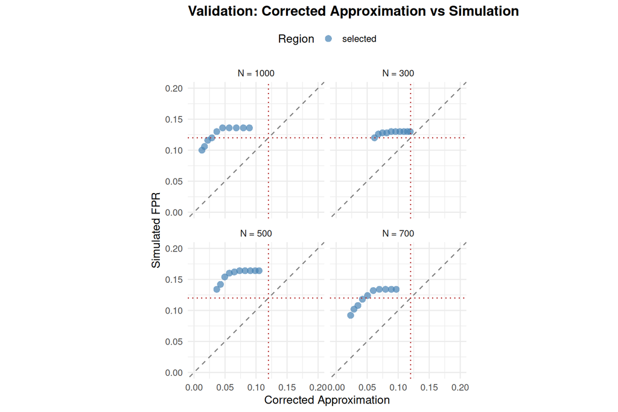

Corrected approximation vs simulated FPR.

```r
if (run_validation) {
  print(
    ggplot(val_fpr, aes(x = FPR_corr, y = Sim_FPR)) +
      geom_abline(slope = 1, intercept = 0, linetype = "dashed",
                  colour = "grey50") +
      geom_point(aes(colour = region, shape = region), size = 3,
                 alpha = 0.7) +
      geom_hline(yintercept = fpr_target, linetype = "dotted",
                 colour = "firebrick") +
      geom_vline(xintercept = fpr_target, linetype = "dotted",
                 colour = "firebrick") +
      scale_colour_manual(
        values = c("selected" = "steelblue",
                   "boundary" = "orange")) +
      facet_wrap(~ paste("N =", N)) +
      coord_equal(
        xlim = c(0, max(val_fpr$FPR_corr, 0.20)),
        ylim = c(0, max(val_fpr$Sim_FPR, 0.20))) +
      labs(x = "Corrected Approximation",
           y = "Simulated FPR",
           title = "Validation: Corrected Approximation vs Simulation",
           colour = "Region", shape = "Region") +
      theme_minimal(base_size = 12) +
      theme(legend.position = "top",
            plot.title = element_text(face = "bold"))
  )
} else {
  cat("Scatter plot skipped (nsims_val = 0).\n")
}
```

## 7.3 Confirmed Acceptable Pairs

```r
if (run_validation) {
  confirmed <- val_fpr[Sim_FPR <= fpr_target &
                        FPR_corr <= fpr_target]
  setorder(confirmed, N, -Sim_FPR)

  if (nrow(confirmed) > 0) {
    gt(confirmed[, .(N, c1, c2,
      `Corr FPR` = sprintf("%.1f%%", 100 * FPR_corr),
      `95% CI` = sprintf("[%.1f%%, %.1f%%]",
        100 * CI_lower, 100 * CI_upper),
      `Sim FPR` = sprintf("%.1f%%", 100 * Sim_FPR),
      `Sim/Corr` = round(Sim_FPR / pmax(FPR_corr, 0.001), 2),
      `In CI` = ifelse(in_CI, "Yes", "No")
    )]) |>
      tab_header(
        title = md(sprintf(
          "**Confirmed Pairs: FPR <= %.0f%% (Approx AND Sim)**",
          100 * fpr_target)),
        subtitle = sprintf("%d sims per config", nsims_val)
      ) |>
      tab_style(style = cell_fill(color = "#E8F5E9"),
        locations = cells_body(columns = `In CI`,
          rows = `In CI` == "Yes")) |>
      tab_style(style = cell_fill(color = "#FFEBEE"),
        locations = cells_body(columns = `In CI`,
          rows = `In CI` == "No")) |>
      tab_source_note(paste(
        "95% CI bounds treat Corr FPR as the true rate.",
        "'In CI' = simulated FPR falls within expected range."))
  } else {
    cat("No pairs confirmed at this sim count.\n")
  }
} else {
  confirmed <- selected
  confirmed[, N := NA_integer_]
  cat("No simulation validation (nsims_val = 0).\n")
  cat(sprintf(
    "Approximation-selected pairs (corrected FPR <= %.0f%%): %d\n",
    100 * fpr_target, nrow(confirmed)))
}
```

Confirmed acceptable pairs

**Confirmed Pairs: FPR <= 12% (Approx AND Sim)**

500 sims per config

| N | c1 | c2 | Corr FPR | 95% CI | Sim FPR | Sim/Corr | In CI |
| --- | --- | --- | --- | --- | --- | --- | --- |
| 300 | 1.45 | 0.9 | 6.2% | [4.1%, 8.3%] | 12.0% | 1.94 | No |
| 700 | 1.30 | 0.9 | 4.2% | [2.5%, 6.0%] | 11.8% | 2.79 | No |
| 700 | 1.35 | 0.9 | 3.5% | [1.9%, 5.1%] | 10.8% | 3.09 | No |
| 700 | 1.40 | 0.9 | 2.9% | [1.4%, 4.3%] | 10.2% | 3.55 | No |
| 700 | 1.45 | 0.9 | 2.3% | [1.0%, 3.7%] | 9.2% | 3.95 | No |
| 1000 | 1.30 | 0.9 | 2.9% | [1.4%, 4.3%] | 12.0% | 4.18 | No |
| 1000 | 1.35 | 0.9 | 2.2% | [0.9%, 3.5%] | 11.6% | 5.24 | No |
| 1000 | 1.40 | 0.9 | 1.7% | [0.6%, 2.8%] | 10.6% | 6.26 | No |
| 1000 | 1.45 | 0.9 | 1.3% | [0.3%, 2.3%] | 10.0% | 7.83 | No |

95% CI bounds treat Corr FPR as the true rate. 'In CI' = simulated FPR falls within expected range.